# Aula 5 - Analise e Tratamento de um banco de dados

Esta aula é baseada no material postado no [Rpubs](https://rpubs.com/belisards/tutorial-corona)

Claudiano Cruz Neto

2021-08-11

# Pacotes utilizados

```r
# Pacotes
library(tidyverse)
```

# Importando os Dados

Nessa etapa iremos relembrar algumas funções úteis para trabalhar com dados importados de outras fontes. Para isso, usaremos os dados de COVID-19 oriúndos do repositório da [Johns Hopkins University](https://github.com/CSSEGISandData/COVID-19).

```r
# url que usaremos para baixar os dados
url <- 'https://raw.githubusercontent.com/CSSEGISandData/COVID-19/master/csse_covid_19_data/csse_covid_19_time_series/time_series_covid19_confirmed_global.csv'

# Importando o arquivo csv
dados <- read.csv(url)
```

Depois de baixarmos os dados, precisamos entender sua estrutura. Para isso vamos usar algumas funções específicas para essa finalidade.

```r
dados %>% head()
```

|  | Province.State | Country.Region | Lat | Long | X1.22.20 | X1.23.20 | X1.24.20 | X1.25.20 | X1.26.20 | X1.27.20 | X1.28.20 | X1.29.20 | X1.30.20 | X1.31.20 | X2.1.20 | X2.2.20 | X2.3.20 | X2.4.20 | X2.5.20 | X2.6.20 | X2.7.20 | X2.8.20 | X2.9.20 | X2.10.20 | X2.11.20 | X2.12.20 | X2.13.20 | X2.14.20 | X2.15.20 | … |
| --- | --- | --- | --- | --- | --- | --- | --- | --- | --- | --- | --- | --- | --- | --- | --- | --- | --- | --- | --- | --- | --- | --- | --- | --- | --- | --- | --- | --- | --- | --- |
| 1 |  | Afghanistan | 33.93911 | 67.70995 | 0 | 0 | 0 | 0 | 0 | 0 | 0 | 0 | 0 | 0 | 0 | 0 | 0 | 0 | 0 | 0 | 0 | 0 | 0 | 0 | 0 | 0 | 0 | 0 | 0 | … |
| 2 |  | Albania | 41.15330 | 20.16830 | 0 | 0 | 0 | 0 | 0 | 0 | 0 | 0 | 0 | 0 | 0 | 0 | 0 | 0 | 0 | 0 | 0 | 0 | 0 | 0 | 0 | 0 | 0 | 0 | 0 | … |
| 3 |  | Algeria | 28.03390 | 1.65960 | 0 | 0 | 0 | 0 | 0 | 0 | 0 | 0 | 0 | 0 | 0 | 0 | 0 | 0 | 0 | 0 | 0 | 0 | 0 | 0 | 0 | 0 | 0 | 0 | 0 | … |
| 4 |  | Andorra | 42.50630 | 1.52180 | 0 | 0 | 0 | 0 | 0 | 0 | 0 | 0 | 0 | 0 | 0 | 0 | 0 | 0 | 0 | 0 | 0 | 0 | 0 | 0 | 0 | 0 | 0 | 0 | 0 | … |
| 5 |  | Angola | -11.20270 | 17.87390 | 0 | 0 | 0 | 0 | 0 | 0 | 0 | 0 | 0 | 0 | 0 | 0 | 0 | 0 | 0 | 0 | 0 | 0 | 0 | 0 | 0 | 0 | 0 | 0 | 0 | … |
| 6 |  | Antigua and Barbuda | 17.06080 | -61.79640 | 0 | 0 | 0 | 0 | 0 | 0 | 0 | 0 | 0 | 0 | 0 | 0 | 0 | 0 | 0 | 0 | 0 | 0 | 0 | 0 | 0 | 0 | 0 | 0 | 0 | … |

Observe que podemos acessar os dados acima e ver sua estrutura. Note que o dataset `dados` possue 279 linhas e 571 colunas. Para acessar esses valores, usamos as funções `nrow()` e `ncol()`, respectivamente. Teste você também!

```r
# teste as funções ditas acima:
```

Ao navegar pela tabela observamos as seguintes colunas:

- *Province.State* (província, por exemplo, Guiana Francesa)
- *Country.Region* (país, por exemplo, França)
- *Lat* (latitude)
- *Long* (longitude)
- *Datas* (são várias colunas representando diferentes datas)

Devemos observar logo de imediato que as colunas com a grafia *“X1.16.21”* registram uma série histórica de cada país. Cada dia é uma coluna.

```r
# mudando nome para pais.
dados <- dados %>% rename(pais = Country.Region)
```

# Precisamos mudar o formato de colunas em linhas

```r
dados2 <- dados %>%
  filter(pais %in% c("Brazil", "Argentina", "Chile", "US")) %>% # podemos retirar esse filtro.
  pivot_longer(cols = starts_with("X"), names_to = "dia", values_to = "n_casos") %>%
  as_tibble()
```

Vejamos apenas que estamos usando também uma função chamada `starts_with()` dentro do argumento `cols` porque percebemos um padrão nos nomes das colunas que desejamos alterar. Você notou esse padrão?

Agora vejamos como os dados estão:

```r
str(dados2)
```

```
## tibble [2,268 x 6] (S3: tbl_df/tbl/data.frame)
##  $ Province.State: chr [1:2268] "" "" "" "" ...
##  $ pais          : chr [1:2268] "Argentina" "Argentina" "Argentina" "Argentina" ...
##  $ Lat           : num [1:2268] -38.4 -38.4 -38.4 -38.4 -38.4 ...
##  $ Long          : num [1:2268] -63.6 -63.6 -63.6 -63.6 -63.6 ...
##  $ dia           : chr [1:2268] "X1.22.20" "X1.23.20" "X1.24.20" "X1.25.20" ...
##  $ n_casos       : int [1:2268] 0 0 0 0 0 0 0 0 0 0 ...
```

Ou podemos usar:

```r
glimpse(dados2)
```

```
## Rows: 2,268
## Columns: 6
## $ Province.State <chr> "", "", "", "", "", "", "", "", "", "", "", "", "", "",~
## $ pais           <chr> "Argentina", "Argentina", "Argentina", "Argentina", "Ar~
## $ Lat            <dbl> -38.4161, -38.4161, -38.4161, -38.4161, -38.4161, -38.4~
## $ Long           <dbl> -63.6167, -63.6167, -63.6167, -63.6167, -63.6167, -63.6~
## $ dia            <chr> "X1.22.20", "X1.23.20", "X1.24.20", "X1.25.20", "X1.26.~
## $ n_casos        <int> 0, 0, 0, 0, 0, 0, 0, 0, 0, 0, 0, 0, 0, 0, 0, 0, 0, 0, 0~
```

# Verificando `NAs`

Dados ausentes - NAs ou valores não-disponíveis - representam muitas dificuldades para os métodos de análise. Encontrar dados ausentes é tão importante que existem no R funções projetadas especificamente para encontrá-los. A função `is.na()` é otimizada para pesquisar grandes conjuntos de dados e encontra rapidamente valores ausentes.

Se buscamos saber em quais colunas estão os dados faltantes, vejamos a função `table()` pode ser utilizada inicialmente para verificar a quantidade total de NAs em seus dados.

```r
table(is.na(dados2)) # verifica a presença ou não de NAs
```

```
##
## FALSE
## 13608
```

E `colSums()` permite verificar todo o data frame de modo vetorizado.

```r
colSums(is.na(dados2))
```

```
## Province.State           pais            Lat           Long            dia
##              0              0              0              0              0
##        n_casos
##              0
```

Felizmente não temos dados faltantes na nossa tabela, e isso pode ser inferido a partir dos valores nulos nas colunas destacadas acima.

# Precisamos transformar texto em datas - strings to date

Ao olhar para o dataset você consegue realmente entender o que a coluna `dia` representa? Infelizmente o formato dos dados não está muito claro, mas sabemos que a primeira parte representa `mês` antecedido da letra *X*, depois `dia` e depois `ano`, esse ultimo com apenas 2 dígitos.

Entendo que o primeiro passo aqui seja definir que o campo `dia` seja declarado como uma `date`. No momento vamos retirar a letra *“X”*, e depois formatar a coluna como data.

Usamos uma função para substituir (replace) uma sequência de caracteres (string ou str), `str_replace()`. Com ela, vamos trocar no campo “dia” do banco de dados “dados2” qualquer ocorrência de *X* por uma sequência vazia. *O que isso significa dizer?*

```r
# dados2 %>%
#   mutate(dia = str_replace(dia, "X", "")) %>%
#   lubridate::as_date(dados2$dia, format = "%m.%d.%y")

# jeito r Base
dados2$dia <- str_replace(dados2$dia,"X", "") %>%
  as.Date(format='%m.%d.%y')
```

Depois de substituidos os “X”s, mudamos a coluna `dia` para o formato de data com a função `as.Date()`. Note que, adotamos data que é mês (%m), dia (%d) e ano (%y).

# Identificando o dia zero x Número de casos

Em análise de dados de epidemias é muito interessante usarmos métricas adequadas. Uma dessas métricas é a contagem de quantos dias se passaram desde determinado limiar de casos. Essa métrica facilita a comparação do mesmo fenômeno que vem ocorrendo em diferentes datas.

```r
dados3 <- dados2 %>%
  arrange(dia) %>% # Ordenando os dados por por dia
  filter(n_casos > 0)  %>%
  group_by(pais) %>% # Agrupando para cada país
  mutate(dia0 = min(dia))  # VDefinindo o dia 0 como o menor dia do país em questão
```

```r
dados3
```

| Province.State | pais | Lat | Long | dia | n_casos | dia0 |
| --- | --- | --- | --- | --- | --- | --- |
|  | US | 40.0000 | -100.0000 | 2020-01-22 | 1 | 2020-01-22 |
|  | US | 40.0000 | -100.0000 | 2020-01-23 | 1 | 2020-01-22 |
|  | US | 40.0000 | -100.0000 | 2020-01-24 | 2 | 2020-01-22 |
|  | US | 40.0000 | -100.0000 | 2020-01-25 | 2 | 2020-01-22 |
|  | US | 40.0000 | -100.0000 | 2020-01-26 | 5 | 2020-01-22 |
|  | US | 40.0000 | -100.0000 | 2020-01-27 | 5 | 2020-01-22 |
|  | US | 40.0000 | -100.0000 | 2020-01-28 | 5 | 2020-01-22 |
|  | US | 40.0000 | -100.0000 | 2020-01-29 | 6 | 2020-01-22 |
|  | US | 40.0000 | -100.0000 | 2020-01-30 | 6 | 2020-01-22 |
|  | US | 40.0000 | -100.0000 | 2020-01-31 | 8 | 2020-01-22 |

[output cut: 2150 more lines]

Agora que temos a variável `dia0` - a data de registro do primeiro caso de coronavirus podemos calcular a como a pandemia está avançando dia a dia, e consequentemente poderemos medir sua velocidade. Em outras palavras, podemos analisar como cada país estava uma semana em relação ao limiar do centésimo caso, por exemplo.

Vamos criar uma nova variável `conta_dia` que vai ser o resultado da diferença entre a data de registro `dia` e o dia 0 `dia0` em dias.

```r
dados4 <- dados3 %>%
  mutate(conta_dia = difftime(dia, dia0, units = "days"))


# E visualizar os dados ordernados por ele
dados4 %>% arrange(conta_dia)
```

| Province.State | pais | Lat | Long | dia | n_casos | dia0 | conta_dia |
| --- | --- | --- | --- | --- | --- | --- | --- |
|  | US | 40.0000 | -100.0000 | 2020-01-22 | 1 | 2020-01-22 | 0 days |
|  | Chile | -35.6751 | -71.5430 | 2020-02-23 | 2 | 2020-02-23 | 0 days |
|  | Brazil | -14.2350 | -51.9253 | 2020-02-26 | 1 | 2020-02-26 | 0 days |
|  | Argentina | -38.4161 | -63.6167 | 2020-03-03 | 1 | 2020-03-03 | 0 days |
|  | US | 40.0000 | -100.0000 | 2020-01-23 | 1 | 2020-01-22 | 1 days |
|  | Chile | -35.6751 | -71.5430 | 2020-02-24 | 2 | 2020-02-23 | 1 days |
|  | Brazil | -14.2350 | -51.9253 | 2020-02-27 | 1 | 2020-02-26 | 1 days |
|  | Argentina | -38.4161 | -63.6167 | 2020-03-04 | 1 | 2020-03-03 | 1 days |
|  | US | 40.0000 | -100.0000 | 2020-01-24 | 2 | 2020-01-22 | 2 days |
|  | Chile | -35.6751 | -71.5430 | 2020-02-25 | 2 | 2020-02-23 | 2 days |

[output cut: 2150 more lines]

# Métricas adicionais: Casos novos por dia e aumento percentual

Repare que a coluna `n_casos` traz o total de casos acumulado até a data especificada no campo `dia`. Mas suponha que desejemos conhecer o número de novos casos por dia?

Vamos criar uma nova coluna chamada `novos_casos`, que será resultado do número de casos do dia menos o número de casos do dia anterior, em cada país.

```r
dados5 <- dados4 %>%
       group_by(pais) %>%
arrange(dia) %>% # ordenados por dia
mutate(novos_casos = n_casos - lag(n_casos)) # lag() dá o último valor da col
```

Também vamos adicionar novos campos para mostrar o aumento percentual no número acumulado de casos confirmados diariamente a média móvel de novos casos nos últimos 7 dias.

Para calcular o aumento percentual, tomamos o número de novos casos e dividimos pelo total do dia anterior `lag(n_casos)`, e multiplicamos por 100 para obter a taxa percentual - note ainda, que usamos a função `round()` para imprimir os valores à esquerda da virgula - ou seja, arredondamos os valores.

```r
dados6 <- dados5 %>%
mutate(var_casos = round((novos_casos/lag(n_casos)*100))) %>% # cal variação
mutate(var_casos = paste(var_casos, "%", sep = " ")) # inserindo %
```

# Você se lembra da famosa *Média Móvel simples*?

Essa métrica nos ajuda a enxegarmos as tendências de série temporais, pois ela “suaviza” as possiveis oscilações diárias. Para realizar essa operação precisamos adicionar um novo campo, que servirá para incluí-la. Para isso usaremos a função que irá somar os registros de novos casos nos últimos 7 dias para cada país e fazer um média.

```r
dados7 <- dados6 %>%
  mutate(med_movel_7 = round(zoo::rollmeanr(novos_casos, 7, fill = NA)))
```

# Casos por milhão de habitantes: o que devemos fazer?

Gostariamos de saber qual o número de casos de covid por milhão de habitantes de cada país. O que podemos fazer para resolver isso? *Tente resolver essa demanda!*

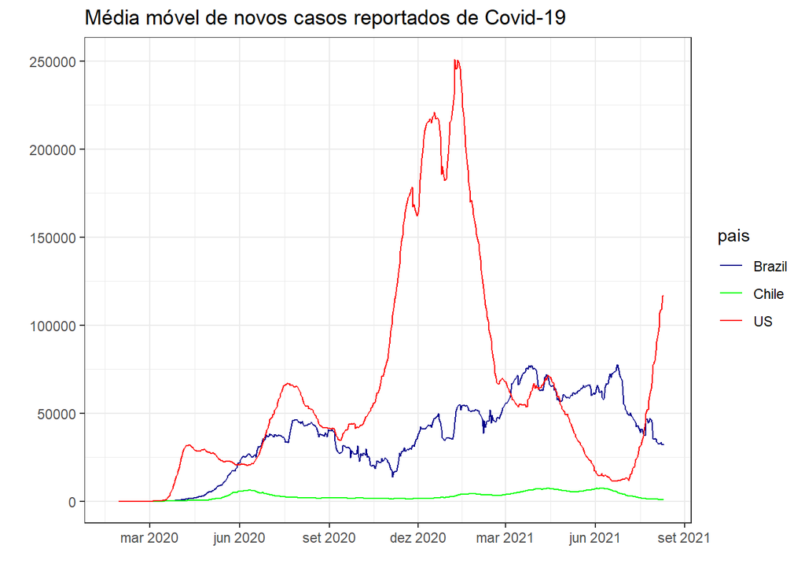

```r
p <- dados7 %>%
  filter(pais %in% c("US", "Brazil", "Chile")) %>%
  group_by(conta_dia)

  p  %>%
  ggplot(aes(x = dia, y = med_movel_7)) +
  geom_line(aes(color = pais)) +
  scale_color_manual(values = c("darkblue", "green", "red")) +
  scale_x_date(breaks = "3 month", date_labels = "%b %Y") +
  #geom_smooth(aes(y = novos_casos), colour="#CC0000") +
  theme_bw() +
  labs(y = "", x = "", title = "Média móvel de novos casos reportados de Covid-19")
```

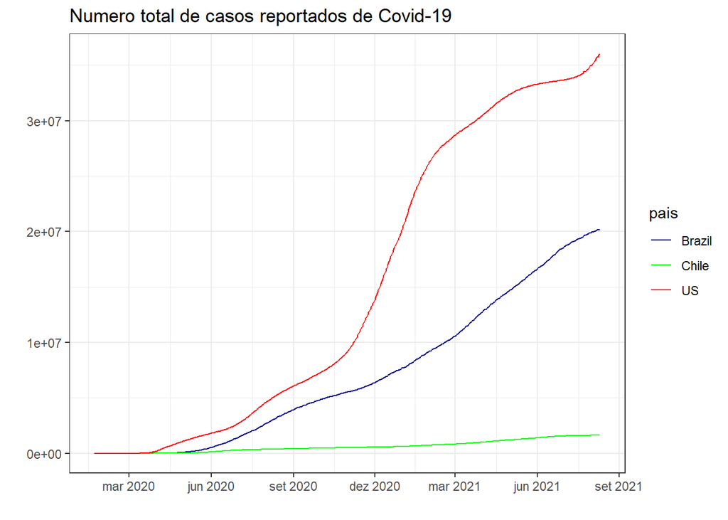

```r
g <- dados7 %>%
  filter(pais %in% c("US", "Brazil", "Chile")) %>%
  group_by(conta_dia)

  g  %>%
  ggplot(aes(x = dia, y = n_casos)) +
  geom_line(aes(color = pais)) +
  scale_color_manual(values = c("darkblue", "green", "red")) +
  scale_x_date(breaks = "3 month", date_labels = "%b %Y") +
  #geom_smooth(aes(y = novos_casos), colour="#CC0000") +
  theme_bw() +
  labs(y = "", x = "", title = "Numero total de casos reportados de Covid-19")
```